# DATA252: Classification Trees and Aggregation Methods

## Learning Objectives

In this lesson students will learn …

- Implement and interpret classification tree in R
- Learn how to prune a tree
- Identify and discuss loss functions for classification methods
- Apply tree aggregation methods (bagging, random forest, boosting)
- Critically evaluate tree models for their advantages and disadvantages.

## Data Inspiration

Motivation/Background:

- “The Pima Indians of Arizona have the highest reported prevalences of obesity and non-insulin-dependent diabetes mellitus (NIDDM). In parallel with abrupt changes in lifestyle, these prevalences in Arizona Pimas have increased to epidemic proportions during the past decades.” (Ravussin et al. 1994)
- “This study provides compelling evidence that changes in lifestyle associated with Westernization play a major role in the global epidemic of type 2 diabetes.” (Schultz et al. 2006)

Sources:

- https://www.ncbi.nlm.nih.gov/pmc/articles/PMC8943493/
- https://diabetesjournals.org/care/article/17/9/1067/17885/Effects-of-a-Traditional-Lifestyle-on-Obesity-in
- https://diabetesjournals.org/care/article/29/8/1866/28611/Effects-of-Traditional-and-Western-Environments-on

#### Step 1: Import the Data

```r
pima<-read.csv("https://raw.githubusercontent.com/kitadasmalley/DATA252/main/Data/diabetes.csv",
               header=TRUE)

pima$Outcome<-as.factor(pima$Outcome)

str(pima)
```

```
## 'data.frame':    768 obs. of  9 variables:
##  $ Pregnancies             : int  6 1 8 1 0 5 3 10 2 8 ...
##  $ Glucose                 : int  148 85 183 89 137 116 78 115 197 125 ...
##  $ BloodPressure           : int  72 66 64 66 40 74 50 0 70 96 ...
##  $ SkinThickness           : int  35 29 0 23 35 0 32 0 45 0 ...
##  $ Insulin                 : int  0 0 0 94 168 0 88 0 543 0 ...
##  $ BMI                     : num  33.6 26.6 23.3 28.1 43.1 25.6 31 35.3 30.5 0 ...
##  $ DiabetesPedigreeFunction: num  0.627 0.351 0.672 0.167 2.288 ...
##  $ Age                     : int  50 31 32 21 33 30 26 29 53 54 ...
##  $ Outcome                 : Factor w/ 2 levels "0","1": 2 1 2 1 2 1 2 1 2 2 ...
```

#### Step 2: Training and Testing

We will use stratified splitting to create 70/30 - training/testing datasets to build our models.

Note: We will use the same seed as we did for the knn example so that we can compare.

```r
library(caret)
# Split the data into training and test set
set.seed(252)
caretSamp <- createDataPartition(pima$Outcome ,
                                        p = 0.7,
                                        list = FALSE)

## SPLIT TESTING AND TRAINING
trainCaret  <- pima[caretSamp, ]
testCaret <- pima[-caretSamp, ]
```

## Single Classification Tree

#### Step 3: Classification Tree

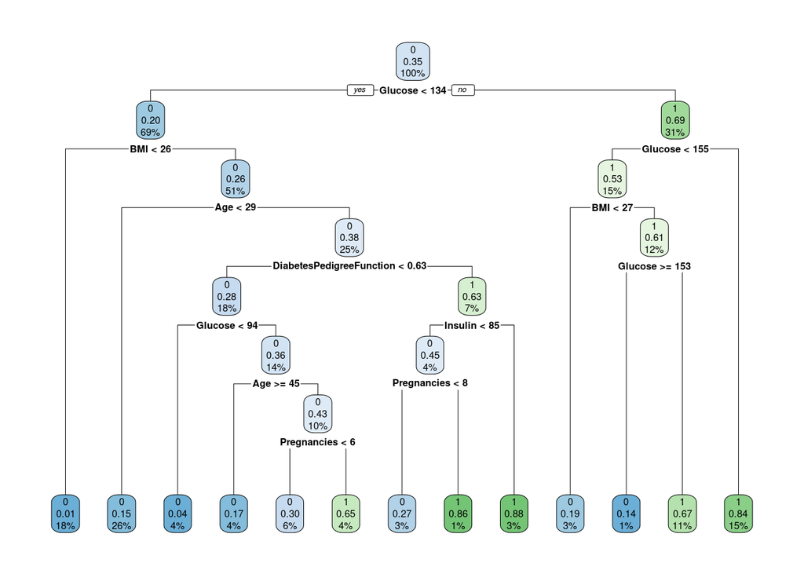

```r
set.seed(252)
library(rpart)

classTree<- rpart(Outcome ~ .,
                  data = trainCaret,
                  method = "class")

### PLOT TREE
library(rpart.plot)
rpart.plot(classTree)
```

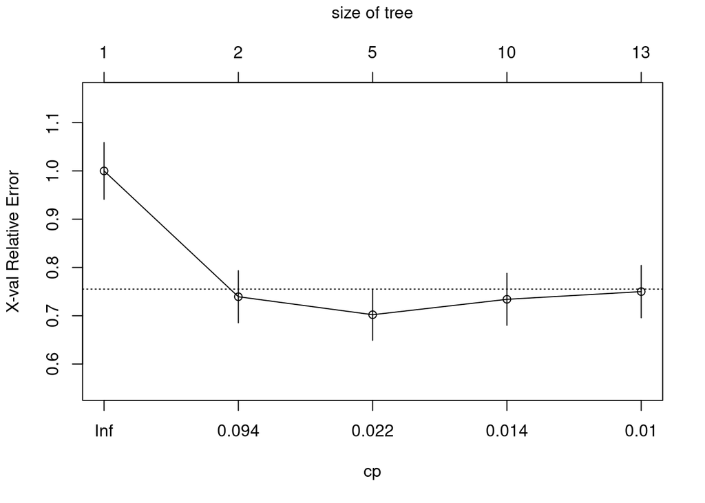

```r
### Plot CP
plotcp(classTree)
```

```r
printcp(classTree)
```

```
##
## Classification tree:
## rpart(formula = Outcome ~ ., data = trainCaret, method = "class")
##
## Variables actually used in tree construction:
## [1] Age                      BMI                      DiabetesPedigreeFunction
## [4] Glucose                  Insulin                  Pregnancies
##
## Root node error: 188/538 = 0.34944
##
## n= 538
##
##         CP nsplit rel error  xerror     xstd
## 1 0.329787      0   1.00000 1.00000 0.058825
## 2 0.026596      1   0.67021 0.73936 0.054006
## 3 0.017730      4   0.59043 0.70213 0.053089
## 4 0.010638      9   0.50000 0.73404 0.053879
## 5 0.010000     12   0.46809 0.75000 0.054257
```

```r
## WHICH CP
minCP<-classTree$cptable[which.min(classTree$cptable[,"xerror"]),"CP"]
```

#### Step 4: Prune the Tree

Find the CP that minimizes the error.

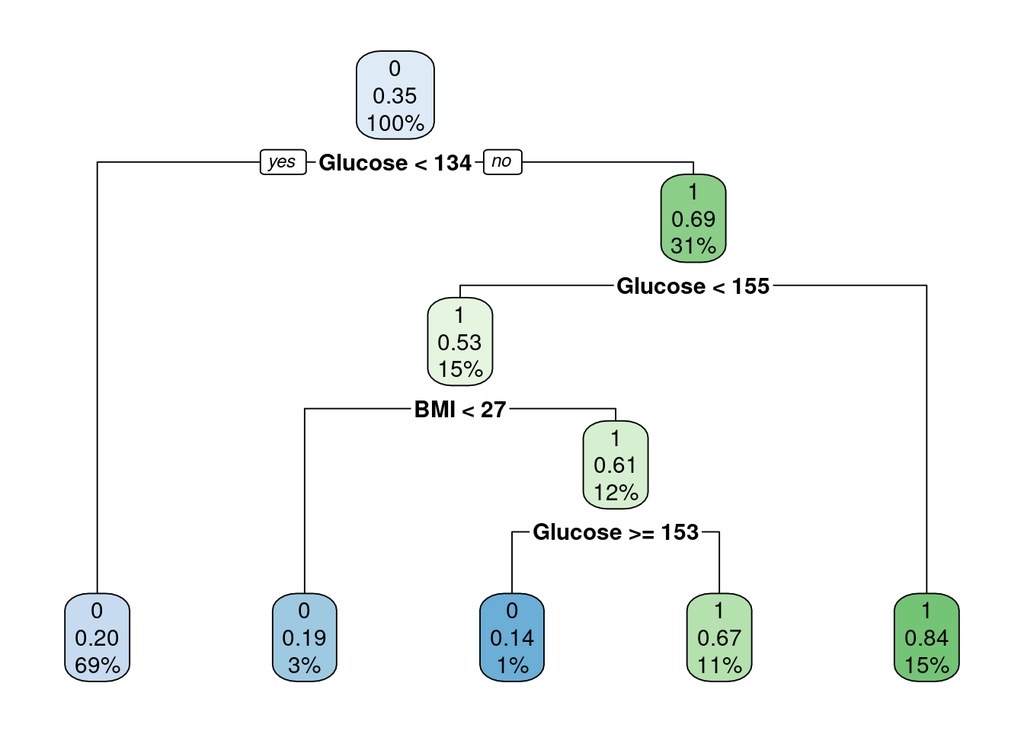

```r
library(rpart.plot)

prune_classTree <- prune(classTree, cp = minCP )
rpart.plot(prune_classTree )
```

#### Step 5: Predict

```r
## DEFAULT TREE
### PREDICT
predTree1<-predict(classTree , testCaret, type="class")

### CONFUSION MATRIX
cmTree1<-table(testCaret$Outcome, predTree1)
cmTree1
```

```
##    predTree1
##       0   1
##   0 114  36
##   1  30  50
```

```r
#### CORRECT RATE
mean(testCaret$Outcome==predTree1)
```

```
## [1] 0.7130435
```

```r
## PRUNED TREE
### PREDICT
predTree2<-predict(prune_classTree , testCaret, type="class")

### CONFUSION MATRIX
cmTree2<-table(testCaret$Outcome, predTree2)
cmTree2
```

```
##    predTree2
##       0   1
##   0 124  26
##   1  42  38
```

```r
#### CORRECT RATE
mean(testCaret$Outcome==predTree2)
```

```
## [1] 0.7043478
```

##### Question:

- What are your observations?

#### Step 6: Trees are Highly Variable

##### Take #2

Try a second random split.

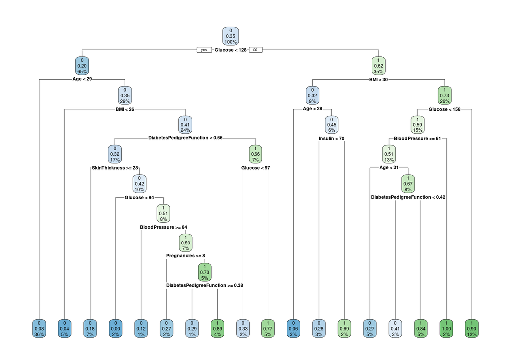

##### Take #3

Try a third random split.

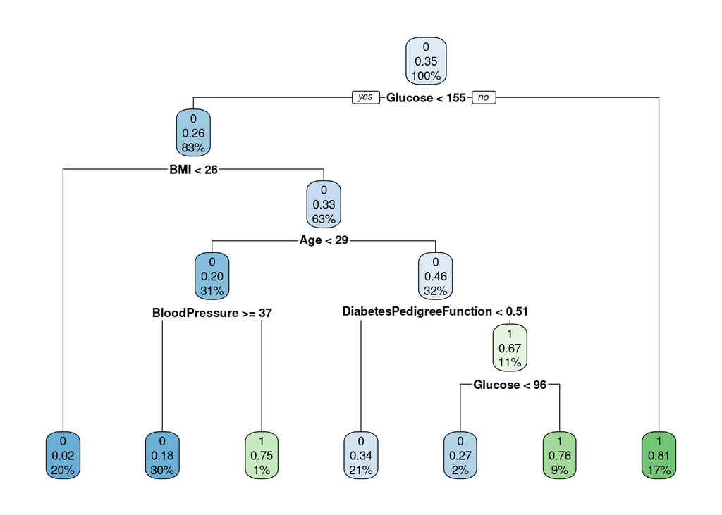

## Bagging

Bagging stands for “bootstrap aggregation”. Random bootstrap samples (with replacement) of the data are used to create trees.

#### Step 7A: Bagging

The big idea is that averaging a set of observations reduces variance; however, you lose the interpretability.

```r
### BAGGING
library(caret)
library(ipred)  #includes the bagging function
library(rpart)

set.seed(252)
pimaBag <- bagging(Outcome ~ .,
                   data = trainCaret,
                   nbagg = 150,
                   coob = TRUE,
                   control = rpart.control(minsplit = 2, cp = 0))

## PREDICT
predBag<-predict(pimaBag, testCaret, type="class")

## CONFUSION MATRIX
cmBag<-table(testCaret$Outcome, predBag)
cmBag
```

```
##    predBag
##       0   1
##   0 123  27
##   1  31  49
```

```r
## CORRECT RATE
mean(testCaret$Outcome==predBag)
```

```
## [1] 0.7478261
```

#### Step 7B: BAG with the Caret Method

```r
library(tidyverse)

### BAG
set.seed(252)
caretBag <- train(Outcome ~.,
               data = trainCaret,
               method = "treebag",
               trControl = trainControl("cv", number = 10),
               importance = TRUE
)

predCaretBag <- caretBag %>% predict(testCaret)

# CONFUSION MATRIX
table(predCaretBag, testCaret$Outcome)
```

```
##
## predCaretBag   0   1
##            0 126  33
##            1  24  47
```

```r
# CORRECT RATE
mean(predCaretBag == testCaret$Outcome)
```

```
## [1] 0.7521739
```

##### Problems with Bagging

Problem with Bagging:

- Trees can be very similar
- Dominated by a few strong / moderately strong predictor
- Bagged trees can be highly correlated
- Does not lead to large reduction in variance when averaging

#### Step 8: Bag Variable Importance

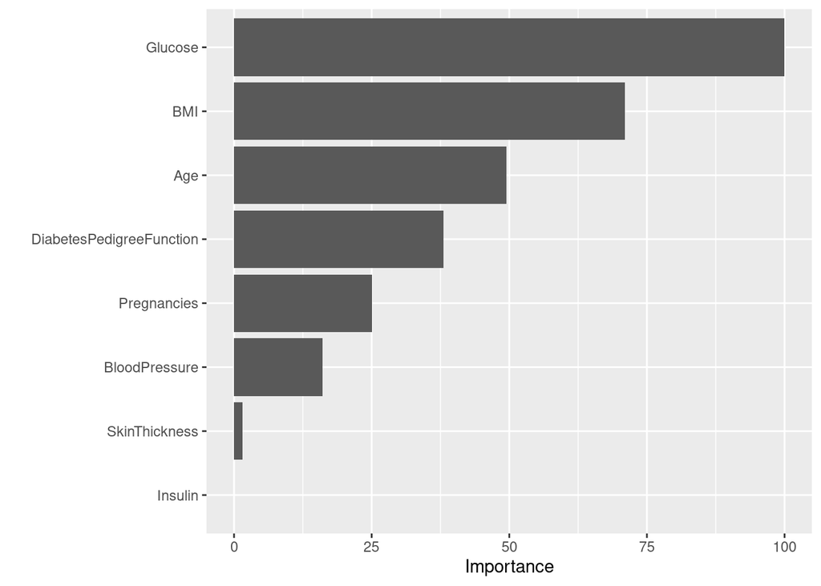

```r
library(vip)
vip(caretBag)
```

## Random Forest

#### Step 9A: Random Forest with Caret

The big idea is to improve on bagging to create decorrelated trees.

When building decision tree, each split only considers a random subset of predictors, $m \approx \sqrt{p}$. A new sample is taken for each split. Therefore, each split is not allowed to consider a majority of the available predictors.

```r
### RF
set.seed(252)
caretRF <- train(Outcome ~.,
               data = trainCaret,
               method = "rf",
               trControl = trainControl("cv", number = 10),
               importance = TRUE
)
# Best tuning parameter
caretRF$bestTune
```

```
##   mtry
## 1    2
```

```r
# Final model
caretRF$finalModel
```

```
##
## Call:
##  randomForest(x = x, y = y, mtry = param$mtry, importance = TRUE)
##                Type of random forest: classification
##                      Number of trees: 500
## No. of variables tried at each split: 2
##
##         OOB estimate of  error rate: 23.98%
## Confusion matrix:
##     0   1 class.error
## 0 297  53   0.1514286
## 1  76 112   0.4042553
```

```r
## PREDICT
predCaretRF <- caretRF %>% predict(testCaret)

## TABLE
table(predCaretRF, testCaret$Outcome)
```

```
##
## predCaretRF   0   1
##           0 125  29
##           1  25  51
```

```r
## MEAN
mean(predCaretRF == testCaret$Outcome)
```

```
## [1] 0.7652174
```

#### Step 9B: Variable Importance RF

```r
library(randomForest)
```

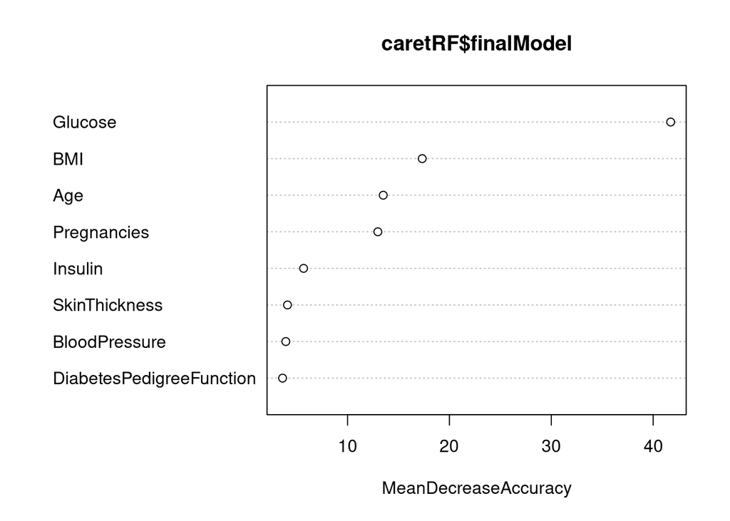

```r
# Plot MeanDecreaseAccuracy
varImpPlot(caretRF$finalModel, type = 1)
```

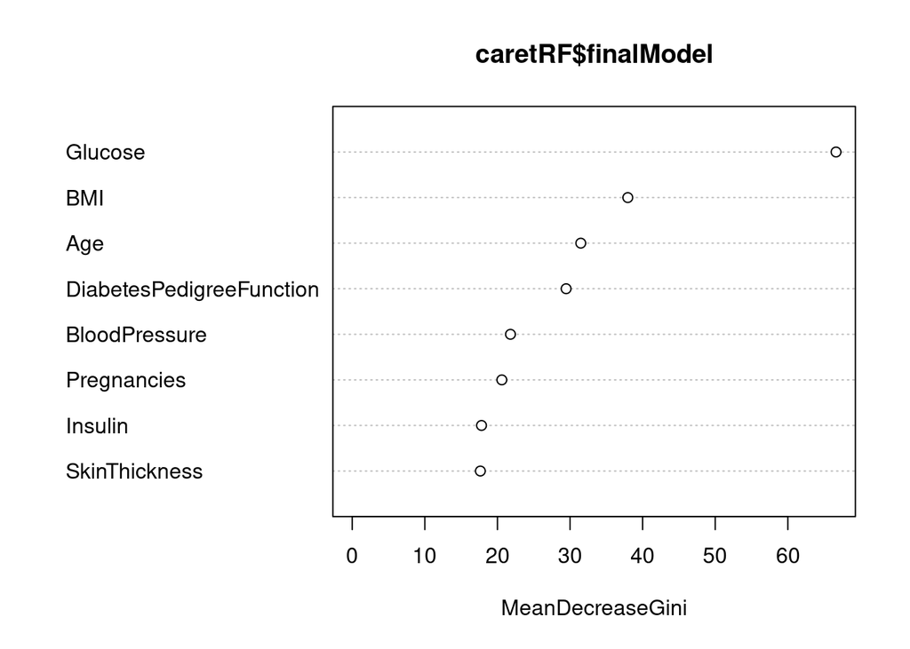

```r
# Plot MeanDecreaseGini
varImpPlot(caretRF$finalModel, type = 2)
```

```r
#library(vip)
#vip(caretRF$finalModel, type = 1)
#vip(caretRF$finalModel, type = 2)
```

## Boosting

The big idea is that trees are grown sequentially. Learns slowly (i.e. updates based on some scaled version of the previous tree). Tends to perform well. Each tree grown using information from previously grown trees. Uses original data and information from residuals

Three tuning parameters:

- $B$ : Number of trees
  - Chosen via cross-validation, because it can overfit
- $\lambda$: Shrinkage parameter
  - Controls learning rate (often 0.01 or 0.001)
- $d$ : Number of splits in each tree
  - Often $d=1$ (stump/single split)

#### Step 10A: Boosting with Caret

```r
library(tidyverse)
#install.packages("xgboost)
library(xgboost)

caretBoost <- train(Outcome ~.,
               data = trainCaret,
               method="xgbTree",
               trControl = trainControl("cv", number = 10),
               verbosity = 0)

# Best tuning parameter
caretBoost$bestTune
```

```
##    nrounds max_depth eta gamma colsample_bytree min_child_weight subsample
## 58      50         1 0.4     0              0.6                1      0.75
```

```r
# Make predictions on the test data
predCaretBoost <- caretBoost %>% predict(testCaret)

## TABLE
table(predCaretBoost, testCaret$Outcome)
```

```
##
## predCaretBoost   0   1
##              0 124  35
##              1  26  45
```

```r
## MEAN
mean(predCaretBoost == testCaret$Outcome)
```

```
## [1] 0.7347826
```